# Final Report: Project - Student acheivement

[figure not shown]

[figure not shown]

# 1 Project motivation

Student performance is a critical area for higher education and in this project we will review the variables associated with improving student performance. Various features are available in the UCI dataset including student grades, demographic, social and school related features (33 other features) and it was collected by using school reports and questionnaires to be able to identify if this student is likely to pass or fail his exam (see https://archive.ics.uci.edu/ml/datasets/student+performance). The dataset is obtained from two subject area namely Mathematics and Portuguese. \The problem that we are trying to solve is to indicate variable or variables that are most significant for a student performance and to cluster or determine the students who are most likely to have success in their exams. This analysis will be important for retention of students and determining students most at risk as well as the needed support for those students. As an example when we have students who are showing a weaker social structure, additional support for that student by the school administration could be applied to improve the student performance. This analysis may be able to determine the different types of teaching strategies for students and the type of modality that is needed for optimal learning.

## 1.1 Objectives

The first hypothesis is that there are some variables that may be significant in determining student success such as strong social structure, extra lessons, extra educational activities. The second hypothesis is by identifying those variables and reducing the number of variables a clustering algorithm could be applied to categorize the students into groups such as students likely to get an A,B,C or D.

The specific objectives of this project is to: 1. Determine the variables in the dataset that are most significant in determining if a student will pass Portuguese or Math. 2. Creation of model to determine cluster of students into 4 groups, students based on grades namely D,C,B,A (0-5,6-10,11-15 and 16-20) respectively.

## 1.2 Explanation of dataset

There are various features available in the UCI dataset including student grades, demographic, social and school related features (33 other features per file) and it was collected by using school reports and questionnaires to be able to identify if a student is likely to pass or fail his exam. When the datasets were joined the following is the dataset information.  
Number of variables 55  
Number of observations 382  
Missing cells 0  
Missing cells (%) 0.0%  
Duplicate rows 0  
Duplicate rows (%) 0.0%  
Total size in memory 164.3 KiB  
Average record size in memory 440.3 B  
Variable types

Categorical 32  
Numeric 9  
Boolean 14

The following are the attributes in the data and the metadata information: Attributes for both student-mat.csv (Math course) and student-por.csv (Portuguese language course) datasets:  
1 school - student’s school (binary: ‘GP’ - Gabriel Pereira or ‘MS’ - Mousinho da Silveira)  
2 sex - student’s sex (binary: ‘F’ - female or ‘M’ - male)  
3 age - student’s age (numeric: from 15 to 22)  
4 address - student’s home address type (binary: ‘U’ - urban or ‘R’ - rural)  
5 famsize - family size (binary: ‘LE3’ - less or equal to 3 or ‘GT3’ - greater than 3)  
6 Pstatus - parent’s cohabitation status (binary: ‘T’ - living together or ‘A’ - apart)  
7 Medu - mother’s education (numeric: 0 - none, 1 - primary education (4th grade), 2 5th to 9th grade, 3 secondary education or 4 higher education)  
8 Fedu - father’s education (numeric: 0 - none, 1 - primary education (4th grade), 2 5th to 9th grade, 3 secondary education or 4 higher education)  
9 Mjob - mother’s job (nominal: ‘teacher’, ‘health’ care related, civil ‘services’ (e.g. administrative or police), ‘at_home’ or ‘other’)  
10 Fjob - father’s job (nominal: ‘teacher’, ‘health’ care related, civil ‘services’ (e.g. administrative or police), ‘at_home’ or ‘other’)  
11 reason - reason to choose this school (nominal: close to ‘home’, school ‘reputation’, ‘course’ preference or ‘other’)  
12 guardian - student’s guardian (nominal: ‘mother’, ‘father’ or ‘other’)  
13 traveltime - home to school travel time (numeric: 1 - <15 min., 2 - 15 to 30 min., 3 - 30 min. to 1 hour, or 4 - >1 hour)  
14 studytime - weekly study time (numeric: 1 - <2 hours, 2 - 2 to 5 hours, 3 - 5 to 10 hours, or 4 - >10 hours)  
15 failures - number of past class failures (numeric: n if 1<=n<3, else 4)  
16 schoolsup - extra educational support (binary: yes or no)  
17 famsup - family educational support (binary: yes or no)  
18 paid - extra paid classes within the course subject (Math or Portuguese) (binary: yes or no)  
19 activities - extra-curricular activities (binary: yes or no)  
20 nursery - attended nursery school (binary: yes or no)  
21 higher - wants to take higher education (binary: yes or no)  
22 internet - Internet access at home (binary: yes or no)  
23 romantic - with a romantic relationship (binary: yes or no)  
24 famrel - quality of family relationships (numeric: from 1 - very bad to 5 - excellent)  
25 freetime - free time after school (numeric: from 1 - very low to 5 - very high)  
26 goout - going out with friends (numeric: from 1 - very low to 5 - very high)  
27 Dalc - workday alcohol consumption (numeric: from 1 - very low to 5 - very high)  
28 Walc - weekend alcohol consumption (numeric: from 1 - very low to 5 - very high)  
29 health - current health status (numeric: from 1 - very bad to 5 - very good)  
30 absences - number of school absences (numeric: from 0 to 93)

# 2. Data preparation procedure and exploratory analysis

## 2.1 Data Procedure

The data preparation procedure first included the importing of the student math and student portugese information into one data frame. The data associated with was first loaded into a math and portugese data frames. The information set was then merged based on demographics based information associated. This created a consolidated dataset with merged information to create various statistical inferences. The data was separated into train and validation with a rule of 75% of the sample in train and 25% in validation.

## 2.2 Data Quality, missing values and treatment of categorical variables

The exploratory data analysis was completed using python (see EDA document attached) and the dataset statistics is shown below as well as the summary statistics associated.

### 2.2.1 Dataset statistics

Number of variables 55  
Number of observations 382  
Missing cells 0  
Missing cells (%) 0.0%  
Duplicate rows 0  
Duplicate rows (%) 0.0%  
Total size in memory 164.3 KiB  
Average record size in memory 440.3 B  
Variable types

Categorical 32  
Numeric 9  
Boolean 14

```r
d1_math=read.table("student-mat.csv",sep=";",header=TRUE)
d2_por=read.table("student-por.csv",sep=";",header=TRUE)

d_consolidated=merge(d1_math,d2_por,by=c("school","sex","age","address","famsize","Pstatus","Medu","Fedu","Mjob","Fjob","reason","nursery","internet"))
print(nrow(d_consolidated)) # 382 students
```

```
## [1] 382
```

```r
head(d_consolidated)
```

|  | school | sex | age | address | famsize | Pstatus | Medu | Fedu | Mjob | Fjob | reason | nursery | internet | guardian.x | traveltime.x | studytime.x | failures.x | schoolsup.x | famsup.x | paid.x | activities.x | higher.x | romantic.x | famrel.x | freetime.x | goout.x | Dalc.x | Walc.x | health.x | … |
| --- | --- | --- | --- | --- | --- | --- | --- | --- | --- | --- | --- | --- | --- | --- | --- | --- | --- | --- | --- | --- | --- | --- | --- | --- | --- | --- | --- | --- | --- | --- |
| 1 | GP | F | 15 | R | GT3 | T | 1 | 1 | at_home | other | home | yes | yes | mother | 2 | 4 | 1 | yes | yes | yes | yes | yes | no | 3 | 1 | 2 | 1 | 1 | 1 | … |
| 2 | GP | F | 15 | R | GT3 | T | 1 | 1 | other | other | reputation | no | yes | mother | 1 | 2 | 2 | yes | yes | no | no | yes | yes | 3 | 3 | 4 | 2 | 4 | 5 | … |
| 3 | GP | F | 15 | R | GT3 | T | 2 | 2 | at_home | other | reputation | yes | no | mother | 1 | 1 | 0 | yes | yes | yes | yes | yes | no | 4 | 3 | 1 | 1 | 1 | 2 | … |
| 4 | GP | F | 15 | R | GT3 | T | 2 | 4 | services | health | course | yes | yes | mother | 1 | 3 | 0 | yes | yes | yes | yes | yes | no | 4 | 3 | 2 | 1 | 1 | 5 | … |
| 5 | GP | F | 15 | R | GT3 | T | 3 | 3 | services | services | reputation | yes | yes | other | 2 | 3 | 2 | no | yes | yes | yes | yes | yes | 4 | 2 | 1 | 2 | 3 | 3 | … |
| 6 | GP | F | 15 | R | GT3 | T | 3 | 4 | services | health | course | yes | yes | mother | 1 | 3 | 0 | yes | yes | yes | yes | yes | no | 4 | 3 | 2 | 1 | 1 | 5 | … |

```r
d_consolidated$Pass_Fail_Por <- as.factor(ifelse(d_consolidated$G3.y < 10, 0, 1))

d_consolidated$Pass_Fail_Math <- as.factor(ifelse(d_consolidated$G3.x < 10, 0, 1))

d_consolidated$sex <- as.factor(ifelse(d_consolidated$sex=='F', 0, 1))

d_consolidated$address <- as.factor(ifelse(d_consolidated$address=='U', 0, 1))

d_consolidated$famsize <- as.factor(ifelse(d_consolidated$famsize=='GT3', 0, 1))

d_consolidated$Pstatus <- as.factor(ifelse(d_consolidated$Pstatus=='T', 0, 1))

#nominal: 'teacher', 'health' care related, civil 'services' (e.g. administrative or police), 'at_home' or 'other'
d_consolidated$Mjob <- as.factor(ifelse(d_consolidated$Mjob == 'teacher', 0,
                          ifelse(d_consolidated$Mjob == 'healther', 1,
                          ifelse(d_consolidated$Mjob == 'serivces', 2,
                           ifelse(d_consolidated$Mjob == 'at_home', 3,4)))))

d_consolidated$Fjob <- as.factor(ifelse(d_consolidated$Fjob == 'teacher', 0,
                          ifelse(d_consolidated$Fjob == 'healther', 1,
                          ifelse(d_consolidated$Fjob == 'serivces', 2,
                           ifelse(d_consolidated$Fjob == 'at_home', 3,4)))))

#reason - reason to choose this school (nominal: close to 'home', school 'reputation', 'course' preference or 'other')
d_consolidated$reason <- as.factor(ifelse(d_consolidated$reason == 'home', 0,
                          ifelse(d_consolidated$reason == 'reputation', 1,
                          ifelse(d_consolidated$reason == 'course', 2,
                           ifelse(d_consolidated$reason == 'other', 3,4)))))


#d_consolidated

write.csv(d_consolidated,"d_consolidated", row.names = FALSE)

summary(d_consolidated)
```

```
##  school   sex          age        address famsize Pstatus      Medu
##  GP:342   0:198   Min.   :15.00   0:301   0:278   0:344   Min.   :0.000
##  MS: 40   1:184   1st Qu.:16.00   1: 81   1:104   1: 38   1st Qu.:2.000
##                   Median :17.00                           Median :3.000
##                   Mean   :16.59                           Mean   :2.806
##                   3rd Qu.:17.00                           3rd Qu.:4.000
##                   Max.   :22.00                           Max.   :4.000
##       Fedu       Mjob    Fjob    reason  nursery   internet   guardian.x
##  Min.   :0.000   0: 62   0: 31   0:110   no : 72   no : 58   father: 91
##  1st Qu.:2.000   3: 53   3: 16   1: 98   yes:310   yes:324   mother:275
##  Median :3.000   4:267   4:335   2:140                       other : 16
##  Mean   :2.565                   3: 34
##  3rd Qu.:4.000
##  Max.   :4.000
##   traveltime.x    studytime.x      failures.x     schoolsup.x famsup.x
##  Min.   :1.000   Min.   :1.000   Min.   :0.0000   no :331     no :144
##  1st Qu.:1.000   1st Qu.:1.000   1st Qu.:0.0000   yes: 51     yes:238
##  Median :1.000   Median :2.000   Median :0.0000
##  Mean   :1.442   Mean   :2.034   Mean   :0.2906
##  3rd Qu.:2.000   3rd Qu.:2.000   3rd Qu.:0.0000
##  Max.   :4.000   Max.   :4.000   Max.   :3.0000
##  paid.x    activities.x higher.x  romantic.x    famrel.x      freetime.x
##  no :205   no :181      no : 18   no :261    Min.   :1.00   Min.   :1.000
##  yes:177   yes:201      yes:364   yes:121    1st Qu.:4.00   1st Qu.:3.000
##                                              Median :4.00   Median :3.000
##                                              Mean   :3.94   Mean   :3.223
##                                              3rd Qu.:5.00   3rd Qu.:4.000
##                                              Max.   :5.00   Max.   :5.000
##     goout.x          Dalc.x          Walc.x        health.x
##  Min.   :1.000   Min.   :1.000   Min.   :1.00   Min.   :1.000
##  1st Qu.:2.000   1st Qu.:1.000   1st Qu.:1.00   1st Qu.:3.000
##  Median :3.000   Median :1.000   Median :2.00   Median :4.000
##  Mean   :3.113   Mean   :1.474   Mean   :2.28   Mean   :3.579
##  3rd Qu.:4.000   3rd Qu.:2.000   3rd Qu.:3.00   3rd Qu.:5.000
##  Max.   :5.000   Max.   :5.000   Max.   :5.00   Max.   :5.000
##    absences.x          G1.x            G2.x            G3.x        guardian.y
##  Min.   : 0.000   Min.   : 3.00   Min.   : 0.00   Min.   : 0.00   father: 91
##  1st Qu.: 0.000   1st Qu.: 8.00   1st Qu.: 8.25   1st Qu.: 8.00   mother:275
##  Median : 3.000   Median :10.50   Median :11.00   Median :11.00   other : 16
##  Mean   : 5.319   Mean   :10.86   Mean   :10.71   Mean   :10.39
```

[output cut: 22 more lines]

```
##  Max.   :5.000   Max.   :5.000   Max.   :5.000   Max.   :5.000
##    absences.y          G1.y            G2.y            G3.y       Pass_Fail_Por
##  Min.   : 0.000   Min.   : 0.00   Min.   : 5.00   Min.   : 0.00   0: 32
##  1st Qu.: 0.000   1st Qu.:10.00   1st Qu.:11.00   1st Qu.:11.00   1:350
##  Median : 2.000   Median :12.00   Median :12.00   Median :13.00
##  Mean   : 3.673   Mean   :12.11   Mean   :12.24   Mean   :12.52
##  3rd Qu.: 6.000   3rd Qu.:14.00   3rd Qu.:14.00   3rd Qu.:14.00
##  Max.   :32.000   Max.   :19.00   Max.   :19.00   Max.   :19.00
##  Pass_Fail_Math
##  0:127
##  1:255
##
##
##
##
```

```r
train_sample = sample(1:nrow(d_consolidated), size=nrow(d_consolidated)*.75, replace=FALSE)
d_consolidated_val = d_consolidated[-train_sample,]
d_consolidated = d_consolidated[train_sample,]


mylogit_Math <- glm(Pass_Fail_Math ~ sex + age + address+famsize+Pstatus+Medu+Fedu+Mjob+Fjob+reason+nursery+internet+guardian.x+traveltime.x+studytime.x+failures.x+schoolsup.x+famsup.x + paid.x   + activities.x +higher.x + romantic.x +   famrel.x   +   freetime.x   +    goout.x        +Dalc.x + Walc.x   +     health.x    +   absences.x     +     G1.x       +     G2.x+Pass_Fail_Por, data = d_consolidated, family = "binomial")
summary(mylogit_Math)
```

```
##
## Call:
## glm(formula = Pass_Fail_Math ~ sex + age + address + famsize +
##     Pstatus + Medu + Fedu + Mjob + Fjob + reason + nursery +
##     internet + guardian.x + traveltime.x + studytime.x + failures.x +
##     schoolsup.x + famsup.x + paid.x + activities.x + higher.x +
##     romantic.x + famrel.x + freetime.x + goout.x + Dalc.x + Walc.x +
##     health.x + absences.x + G1.x + G2.x + Pass_Fail_Por, family = "binomial",
##     data = d_consolidated)
##
## Deviance Residuals:
##    Min      1Q  Median      3Q     Max
##  -8.49    0.00    0.00    0.00    8.49
##
## Coefficients:
##                    Estimate Std. Error   z value Pr(>|z|)
## (Intercept)      -1.972e+15  9.165e+07 -21523205   <2e-16 ***
## sex1              1.152e+12  9.854e+06    116944   <2e-16 ***
## age              -2.218e+14  4.150e+06 -53444226   <2e-16 ***
## address1          1.316e+14  1.167e+07  11271162   <2e-16 ***
## famsize1         -4.784e+13  9.783e+06  -4889771   <2e-16 ***
## Pstatus1          1.505e+14  1.465e+07  10270279   <2e-16 ***
## Medu             -1.218e+13  6.098e+06  -1997337   <2e-16 ***
## Fedu              3.885e+13  5.616e+06   6917990   <2e-16 ***
## Mjob3             8.266e+14  2.091e+07  39537422   <2e-16 ***
## Mjob4             4.959e+14  1.361e+07  36441454   <2e-16 ***
## Fjob3            -2.814e+14  2.560e+07 -10989877   <2e-16 ***
## Fjob4             1.684e+14  1.790e+07   9407942   <2e-16 ***
## reason1          -2.670e+14  1.183e+07 -22566775   <2e-16 ***
## reason2          -3.782e+14  1.045e+07 -36205470   <2e-16 ***
## reason3          -2.589e+13  1.595e+07  -1623201   <2e-16 ***
## nurseryyes       -7.589e+13  1.139e+07  -6660905   <2e-16 ***
## internetyes       2.858e+14  1.263e+07  22621421   <2e-16 ***
## guardian.xmother  3.244e+14  1.058e+07  30665265   <2e-16 ***
## guardian.xother  -5.026e+13  2.115e+07  -2376331   <2e-16 ***
## traveltime.x      3.450e+14  6.310e+06  54678579   <2e-16 ***
## studytime.x       9.753e+12  5.699e+06   1711395   <2e-16 ***
## failures.x        3.914e+13  6.728e+06   5817457   <2e-16 ***
## schoolsup.xyes    7.309e+14  1.365e+07  53554966   <2e-16 ***
## famsup.xyes      -3.147e+14  9.301e+06 -33832997   <2e-16 ***
```

[output cut: 9 more lines]

```
## health.x         -1.031e+14  3.063e+06 -33646741   <2e-16 ***
## absences.x       -2.149e+13  6.269e+05 -34283264   <2e-16 ***
## G1.x              1.936e+14  2.635e+06  73496183   <2e-16 ***
## G2.x              3.110e+14  2.147e+06 144875922   <2e-16 ***
## Pass_Fail_Por1    6.131e+14  1.727e+07  35503879   <2e-16 ***
## ---
## Signif. codes:  0 '***' 0.001 '**' 0.01 '*' 0.05 '.' 0.1 ' ' 1
##
## (Dispersion parameter for binomial family taken to be 1)
##
##     Null deviance:  368.96  on 285  degrees of freedom
## Residual deviance: 2162.62  on 248  degrees of freedom
## AIC: 2238.6
##
## Number of Fisher Scoring iterations: 18
```

```r
mylogit_Por <- glm(Pass_Fail_Por ~ sex + age + address+famsize+Pstatus+Medu+Fedu+Mjob+Fjob+reason+nursery+internet+guardian.y+traveltime.y+studytime.y+failures.y+schoolsup.y+famsup.y + paid.y   + activities.y +higher.y + romantic.y +   famrel.y   +   freetime.y   +    goout.y        +Dalc.y + Walc.y   +     health.y    +   absences.y     +     G1.y      +     G2.y, data = d_consolidated, family = "binomial")
summary(mylogit_Por)
```

```
##
## Call:
## glm(formula = Pass_Fail_Por ~ sex + age + address + famsize +
##     Pstatus + Medu + Fedu + Mjob + Fjob + reason + nursery +
##     internet + guardian.y + traveltime.y + studytime.y + failures.y +
##     schoolsup.y + famsup.y + paid.y + activities.y + higher.y +
##     romantic.y + famrel.y + freetime.y + goout.y + Dalc.y + Walc.y +
##     health.y + absences.y + G1.y + G2.y, family = "binomial",
##     data = d_consolidated)
##
## Deviance Residuals:
##        Min          1Q      Median          3Q         Max
## -6.186e-05   2.100e-08   2.100e-08   2.100e-08   6.017e-05
##
## Coefficients:
##                    Estimate Std. Error z value Pr(>|z|)
## (Intercept)      -3.975e+02  1.020e+06   0.000    1.000
## sex1             -3.885e+00  9.912e+04   0.000    1.000
## age              -7.204e+00  5.738e+04   0.000    1.000
## address1          2.690e+01  1.191e+05   0.000    1.000
## famsize1          1.972e+01  1.284e+05   0.000    1.000
## Pstatus1         -1.676e+01  2.262e+05   0.000    1.000
## Medu              1.003e+01  4.190e+04   0.000    1.000
## Fedu             -2.875e+00  3.450e+04   0.000    1.000
## Mjob3             2.017e+01  2.988e+05   0.000    1.000
## Mjob4            -5.723e+01  1.403e+05   0.000    1.000
## Fjob3             1.373e+02  1.588e+05   0.001    0.999
## Fjob4             7.189e+01  9.847e+04   0.001    0.999
## reason1           2.914e+01  1.942e+05   0.000    1.000
## reason2           8.959e+00  8.438e+04   0.000    1.000
## reason3          -1.697e+01  5.105e+04   0.000    1.000
## nurseryyes       -8.603e+00  1.143e+05   0.000    1.000
## internetyes       3.189e+01  1.837e+05   0.000    1.000
## guardian.ymother -4.251e+01  1.287e+05   0.000    1.000
## guardian.yother   2.969e+01  4.214e+05   0.000    1.000
## traveltime.y     -6.593e+00  5.317e+04   0.000    1.000
## studytime.y       1.521e+01  7.616e+04   0.000    1.000
## failures.y        3.358e+01  5.262e+04   0.001    0.999
## schoolsup.yyes    5.667e+00  1.273e+05   0.000    1.000
## famsup.yyes       1.768e+01  4.118e+04   0.000    1.000
## paid.yyes        -3.974e+01  1.097e+05   0.000    1.000
## activities.yyes  -2.376e+01  1.074e+05   0.000    1.000
## higher.yyes       1.845e+01  9.909e+04   0.000    1.000
## romantic.yyes     1.302e+01  5.501e+04   0.000    1.000
## famrel.y          3.821e+00  2.138e+04   0.000    1.000
## freetime.y        9.128e+00  5.759e+04   0.000    1.000
## goout.y           2.073e+00  6.837e+04   0.000    1.000
## Dalc.y            8.026e+00  4.898e+04   0.000    1.000
## Walc.y           -5.916e+00  4.561e+04   0.000    1.000
## health.y         -8.769e-01  4.170e+04   0.000    1.000
## absences.y        1.257e+00  4.740e+03   0.000    1.000
## G1.y             -3.557e+00  3.721e+04   0.000    1.000
## G2.y              4.448e+01  4.286e+04   0.001    0.999
##
## (Dispersion parameter for binomial family taken to be 1)
##
##     Null deviance: 1.6004e+02  on 285  degrees of freedom
## Residual deviance: 4.0127e-08  on 249  degrees of freedom
## AIC: 74
##
## Number of Fisher Scoring iterations: 25
```

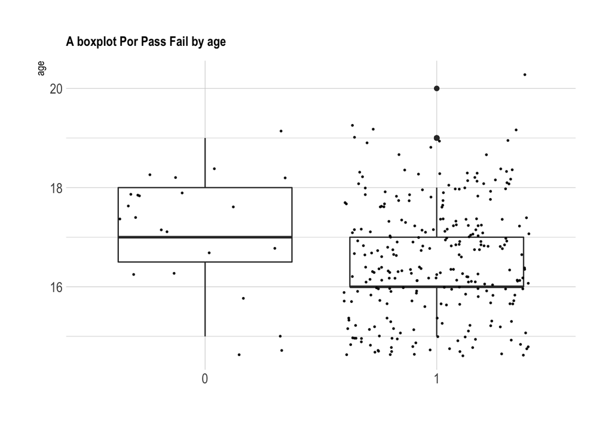

```r
# library
library(ggplot2)
library(dplyr)
library(hrbrthemes)
library(tidyverse)
library(viridis)
d_consolidated %>%
  ggplot( aes(x=Pass_Fail_Por, y=age)) +
    geom_boxplot() +
    scale_fill_viridis(discrete = TRUE, alpha=0.6) +
    geom_jitter(color="black", size=0.4, alpha=0.9) +
    theme_ipsum() +
    theme(
      legend.position="none",
      plot.title = element_text(size=11)
    ) +
    ggtitle("A boxplot Por Pass Fail by age") +
    xlab("")
```

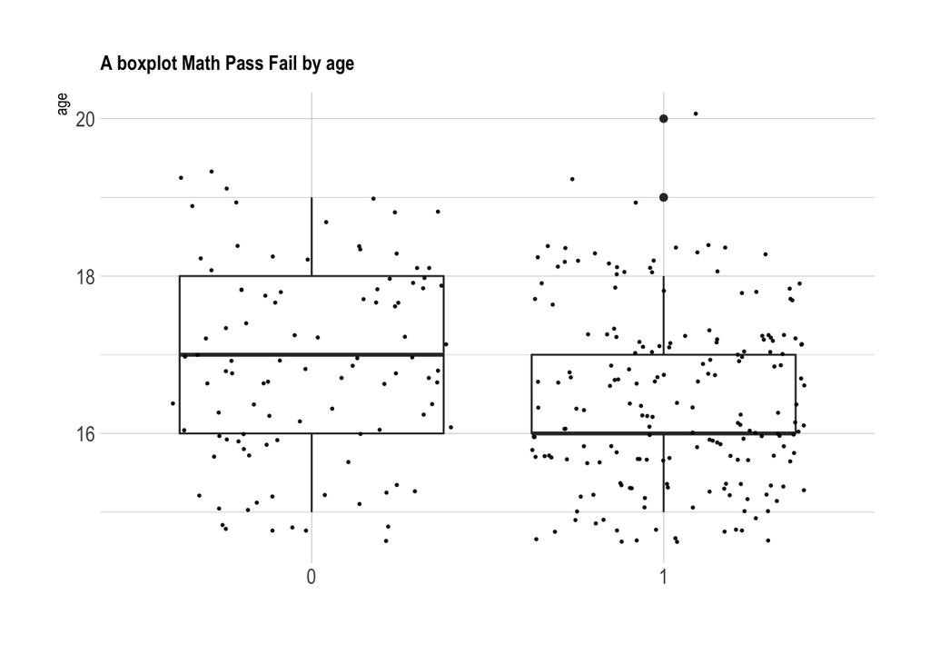

```r
d_consolidated %>%
  ggplot( aes(x=Pass_Fail_Math, y=age)) +
    geom_boxplot() +
    scale_fill_viridis(discrete = TRUE, alpha=0.6) +
    geom_jitter(color="black", size=0.4, alpha=0.9) +
    theme_ipsum() +
    theme(
      legend.position="none",
      plot.title = element_text(size=11)
    ) +
    ggtitle("A boxplot Math Pass Fail by age") +
    xlab("")
```

```r
library(corrplot)
head(d_consolidated)
```

|  | school | sex | age | address | famsize | Pstatus | Medu | Fedu | Mjob | Fjob | reason | nursery | internet | guardian.x | traveltime.x | studytime.x | failures.x | schoolsup.x | famsup.x | paid.x | activities.x | higher.x | romantic.x | famrel.x | freetime.x | goout.x | Dalc.x | Walc.x | health.x | … |
| --- | --- | --- | --- | --- | --- | --- | --- | --- | --- | --- | --- | --- | --- | --- | --- | --- | --- | --- | --- | --- | --- | --- | --- | --- | --- | --- | --- | --- | --- | --- |
| 169 | GP | 0 | 18 | 0 | 1 | 0 | 2 | 2 | 4 | 4 | 0 | no | yes | other | 1 | 2 | 0 | no | no | no | yes | yes | yes | 4 | 3 | 3 | 1 | 1 | 2 | … |
| 234 | GP | 1 | 16 | 0 | 0 | 0 | 3 | 1 | 4 | 4 | 1 | yes | no | mother | 1 | 1 | 0 | no | no | no | yes | yes | no | 5 | 3 | 2 | 2 | 2 | 5 | … |
| 129 | GP | 0 | 17 | 0 | 0 | 0 | 4 | 3 | 4 | 4 | 1 | yes | yes | mother | 1 | 2 | 2 | no | no | yes | no | yes | yes | 3 | 4 | 5 | 2 | 4 | 1 | … |
| 331 | GP | 1 | 18 | 0 | 1 | 0 | 1 | 1 | 4 | 4 | 2 | yes | yes | mother | 1 | 1 | 3 | no | no | no | no | no | yes | 2 | 3 | 5 | 2 | 5 | 4 | … |
| 278 | GP | 1 | 17 | 1 | 0 | 0 | 3 | 4 | 3 | 4 | 2 | yes | no | mother | 3 | 2 | 0 | no | no | no | no | yes | no | 5 | 4 | 5 | 2 | 4 | 5 | … |
| 139 | GP | 0 | 17 | 0 | 1 | 0 | 2 | 4 | 4 | 4 | 2 | yes | yes | father | 1 | 2 | 0 | no | no | no | yes | yes | yes | 4 | 3 | 2 | 1 | 1 | 5 | … |

```r
summary(d_consolidated)
```

```
##  school   sex          age        address famsize Pstatus      Medu
##  GP:254   0:153   Min.   :15.00   0:227   0:207   0:258   Min.   :0.000
##  MS: 32   1:133   1st Qu.:16.00   1: 59   1: 79   1: 28   1st Qu.:2.000
##                   Median :17.00                           Median :3.000
##                   Mean   :16.59                           Mean   :2.783
##                   3rd Qu.:17.00                           3rd Qu.:4.000
##                   Max.   :20.00                           Max.   :4.000
##       Fedu       Mjob    Fjob    reason  nursery   internet   guardian.x
##  Min.   :0.000   0: 45   0: 22   0: 87   no : 50   no : 43   father: 67
##  1st Qu.:2.000   3: 30   3: 14   1: 65   yes:236   yes:243   mother:204
##  Median :3.000   4:211   4:250   2:107                       other : 15
##  Mean   :2.542                   3: 27
##  3rd Qu.:3.750
##  Max.   :4.000
##   traveltime.x    studytime.x      failures.x     schoolsup.x famsup.x
##  Min.   :1.000   Min.   :1.000   Min.   :0.0000   no :247     no :115
##  1st Qu.:1.000   1st Qu.:1.000   1st Qu.:0.0000   yes: 39     yes:171
##  Median :1.000   Median :2.000   Median :0.0000
##  Mean   :1.469   Mean   :1.983   Mean   :0.3112
##  3rd Qu.:2.000   3rd Qu.:2.000   3rd Qu.:0.0000
##  Max.   :4.000   Max.   :4.000   Max.   :3.0000
##  paid.x    activities.x higher.x  romantic.x    famrel.x       freetime.x
##  no :151   no :135      no : 12   no :200    Min.   :1.000   Min.   :1.000
##  yes:135   yes:151      yes:274   yes: 86    1st Qu.:4.000   1st Qu.:3.000
##                                              Median :4.000   Median :3.000
##                                              Mean   :3.923   Mean   :3.259
##                                              3rd Qu.:5.000   3rd Qu.:4.000
##                                              Max.   :5.000   Max.   :5.000
##     goout.x          Dalc.x          Walc.x        health.x      absences.x
##  Min.   :1.000   Min.   :1.000   Min.   :1.00   Min.   :1.00   Min.   : 0.000
##  1st Qu.:2.000   1st Qu.:1.000   1st Qu.:1.00   1st Qu.:3.00   1st Qu.: 0.000
##  Median :3.000   Median :1.000   Median :2.00   Median :4.00   Median : 2.500
##  Mean   :3.122   Mean   :1.486   Mean   :2.29   Mean   :3.58   Mean   : 5.231
##  3rd Qu.:4.000   3rd Qu.:2.000   3rd Qu.:3.00   3rd Qu.:5.00   3rd Qu.: 8.000
##  Max.   :5.000   Max.   :5.000   Max.   :5.00   Max.   :5.00   Max.   :56.000
##       G1.x            G2.x            G3.x        guardian.y   traveltime.y
##  Min.   : 4.00   Min.   : 0.00   Min.   : 0.00   father: 67   Min.   :1.000
##  1st Qu.: 8.00   1st Qu.: 8.00   1st Qu.: 8.00   mother:204   1st Qu.:1.000
##  Median :11.00   Median :11.00   Median :11.00   other : 15   Median :1.000
##  Mean   :10.84   Mean   :10.62   Mean   :10.21                Mean   :1.472
```

[output cut: 15 more lines]

```
##                       Max.   :5.000   Max.   :5.000   Max.   :5.000
##      Dalc.y          Walc.y         health.y       absences.y
##  Min.   :1.000   Min.   :1.000   Min.   :1.000   Min.   : 0.000
##  1st Qu.:1.000   1st Qu.:1.000   1st Qu.:3.000   1st Qu.: 0.000
##  Median :1.000   Median :2.000   Median :4.000   Median : 2.000
##  Mean   :1.493   Mean   :2.297   Mean   :3.584   Mean   : 3.759
##  3rd Qu.:2.000   3rd Qu.:3.000   3rd Qu.:5.000   3rd Qu.: 6.000
##  Max.   :5.000   Max.   :5.000   Max.   :5.000   Max.   :32.000
##       G1.y            G2.y           G3.y       Pass_Fail_Por Pass_Fail_Math
##  Min.   : 5.00   Min.   : 5.0   Min.   : 0.00   0: 23         0: 99
##  1st Qu.:10.00   1st Qu.:11.0   1st Qu.:11.00   1:263         1:187
##  Median :12.00   Median :12.0   Median :13.00
##  Mean   :12.11   Mean   :12.2   Mean   :12.49
##  3rd Qu.:14.00   3rd Qu.:14.0   3rd Qu.:14.00
##  Max.   :18.00   Max.   :19.0   Max.   :19.00
```

```r
mylogit_Math <- glm(Pass_Fail_Math ~ sex + age + address+famsize+Pstatus+Medu+Fedu+Mjob+Fjob+reason+nursery+internet+guardian.x+traveltime.x+studytime.x+failures.x+schoolsup.x+famsup.x + paid.x   + activities.x +higher.x + romantic.x +   famrel.x   +   freetime.x   +    goout.x        +Dalc.x + Walc.x   +     health.x    +   absences.x     +     G1.x       +     G2.x+Pass_Fail_Por, data = d_consolidated, family = "binomial")
summary(mylogit_Math)
```

```
##
## Call:
## glm(formula = Pass_Fail_Math ~ sex + age + address + famsize +
##     Pstatus + Medu + Fedu + Mjob + Fjob + reason + nursery +
##     internet + guardian.x + traveltime.x + studytime.x + failures.x +
##     schoolsup.x + famsup.x + paid.x + activities.x + higher.x +
##     romantic.x + famrel.x + freetime.x + goout.x + Dalc.x + Walc.x +
##     health.x + absences.x + G1.x + G2.x + Pass_Fail_Por, family = "binomial",
##     data = d_consolidated)
##
## Deviance Residuals:
##    Min      1Q  Median      3Q     Max
##  -8.49    0.00    0.00    0.00    8.49
##
## Coefficients:
##                    Estimate Std. Error   z value Pr(>|z|)
## (Intercept)      -1.972e+15  9.165e+07 -21523205   <2e-16 ***
## sex1              1.152e+12  9.854e+06    116944   <2e-16 ***
## age              -2.218e+14  4.150e+06 -53444226   <2e-16 ***
## address1          1.316e+14  1.167e+07  11271162   <2e-16 ***
## famsize1         -4.784e+13  9.783e+06  -4889771   <2e-16 ***
## Pstatus1          1.505e+14  1.465e+07  10270279   <2e-16 ***
## Medu             -1.218e+13  6.098e+06  -1997337   <2e-16 ***
## Fedu              3.885e+13  5.616e+06   6917990   <2e-16 ***
## Mjob3             8.266e+14  2.091e+07  39537422   <2e-16 ***
## Mjob4             4.959e+14  1.361e+07  36441454   <2e-16 ***
## Fjob3            -2.814e+14  2.560e+07 -10989877   <2e-16 ***
## Fjob4             1.684e+14  1.790e+07   9407942   <2e-16 ***
## reason1          -2.670e+14  1.183e+07 -22566775   <2e-16 ***
## reason2          -3.782e+14  1.045e+07 -36205470   <2e-16 ***
## reason3          -2.589e+13  1.595e+07  -1623201   <2e-16 ***
## nurseryyes       -7.589e+13  1.139e+07  -6660905   <2e-16 ***
## internetyes       2.858e+14  1.263e+07  22621421   <2e-16 ***
## guardian.xmother  3.244e+14  1.058e+07  30665265   <2e-16 ***
## guardian.xother  -5.026e+13  2.115e+07  -2376331   <2e-16 ***
## traveltime.x      3.450e+14  6.310e+06  54678579   <2e-16 ***
## studytime.x       9.753e+12  5.699e+06   1711395   <2e-16 ***
## failures.x        3.914e+13  6.728e+06   5817457   <2e-16 ***
## schoolsup.xyes    7.309e+14  1.365e+07  53554966   <2e-16 ***
## famsup.xyes      -3.147e+14  9.301e+06 -33832997   <2e-16 ***
```

[output cut: 9 more lines]

```
## health.x         -1.031e+14  3.063e+06 -33646741   <2e-16 ***
## absences.x       -2.149e+13  6.269e+05 -34283264   <2e-16 ***
## G1.x              1.936e+14  2.635e+06  73496183   <2e-16 ***
## G2.x              3.110e+14  2.147e+06 144875922   <2e-16 ***
## Pass_Fail_Por1    6.131e+14  1.727e+07  35503879   <2e-16 ***
## ---
## Signif. codes:  0 '***' 0.001 '**' 0.01 '*' 0.05 '.' 0.1 ' ' 1
##
## (Dispersion parameter for binomial family taken to be 1)
##
##     Null deviance:  368.96  on 285  degrees of freedom
## Residual deviance: 2162.62  on 248  degrees of freedom
## AIC: 2238.6
##
## Number of Fisher Scoring iterations: 18
```

```r
mylogit_Por <- glm(Pass_Fail_Por ~ sex + age + address+famsize+Pstatus+Medu+Fedu+Mjob+Fjob+reason+nursery+internet+guardian.y+traveltime.y+studytime.y+failures.y+schoolsup.y+famsup.y + paid.y   + activities.y +higher.y + romantic.y +   famrel.y   +   freetime.y   +    goout.y        +Dalc.y + Walc.y   +     health.y    +   absences.y     +     G1.y      +     G2.y+Pass_Fail_Math, data = d_consolidated, family = "binomial")
summary(mylogit_Por)
```

```
##
## Call:
## glm(formula = Pass_Fail_Por ~ sex + age + address + famsize +
##     Pstatus + Medu + Fedu + Mjob + Fjob + reason + nursery +
##     internet + guardian.y + traveltime.y + studytime.y + failures.y +
##     schoolsup.y + famsup.y + paid.y + activities.y + higher.y +
##     romantic.y + famrel.y + freetime.y + goout.y + Dalc.y + Walc.y +
##     health.y + absences.y + G1.y + G2.y + Pass_Fail_Math, family = "binomial",
##     data = d_consolidated)
##
## Deviance Residuals:
##        Min          1Q      Median          3Q         Max
## -5.339e-05   2.100e-08   2.100e-08   2.100e-08   4.814e-05
##
## Coefficients:
##                    Estimate Std. Error z value Pr(>|z|)
## (Intercept)      -3.933e+02  4.980e+05  -0.001    0.999
## sex1             -2.235e+01  5.024e+04   0.000    1.000
## age              -1.806e+00  2.173e+04   0.000    1.000
## address1          2.401e+01  6.585e+04   0.000    1.000
## famsize1          2.253e+01  7.486e+04   0.000    1.000
## Pstatus1         -1.613e+01  1.049e+05   0.000    1.000
## Medu              9.784e+00  2.940e+04   0.000    1.000
## Fedu             -7.451e-01  3.428e+04   0.000    1.000
## Mjob3             3.774e+01  1.912e+05   0.000    1.000
## Mjob4            -4.957e+01  8.365e+04  -0.001    1.000
## Fjob3             1.233e+02  1.788e+05   0.001    0.999
## Fjob4             7.207e+01  7.824e+04   0.001    0.999
## reason1           3.008e+01  8.599e+04   0.000    1.000
## reason2          -4.513e+00  9.116e+04   0.000    1.000
## reason3          -5.593e+00  8.903e+04   0.000    1.000
## nurseryyes       -1.407e+01  6.493e+04   0.000    1.000
## internetyes       2.290e+01  7.481e+04   0.000    1.000
## guardian.ymother -2.082e+01  8.394e+04   0.000    1.000
## guardian.yother   4.197e+01  1.482e+05   0.000    1.000
## traveltime.y     -3.015e+00  5.115e+04   0.000    1.000
## studytime.y       1.694e+01  7.041e+04   0.000    1.000
## failures.y        2.669e+01  3.064e+04   0.001    0.999
## schoolsup.yyes    2.530e+00  9.058e+04   0.000    1.000
## famsup.yyes       3.561e+01  8.047e+04   0.000    1.000
## paid.yyes        -3.622e+01  6.072e+04  -0.001    1.000
## activities.yyes  -7.489e+00  4.583e+04   0.000    1.000
## higher.yyes      -4.327e-01  6.001e+04   0.000    1.000
## romantic.yyes     5.353e+00  6.308e+04   0.000    1.000
## famrel.y         -3.322e+00  2.144e+04   0.000    1.000
## freetime.y        9.054e+00  4.087e+04   0.000    1.000
## goout.y           6.726e+00  4.643e+04   0.000    1.000
## Dalc.y           -2.880e+00  4.867e+04   0.000    1.000
## Walc.y           -1.255e-01  2.581e+04   0.000    1.000
## health.y          6.585e-02  2.326e+04   0.000    1.000
## absences.y        5.969e-01  5.037e+03   0.000    1.000
## G1.y             -5.762e+00  3.764e+04   0.000    1.000
## G2.y              3.689e+01  4.063e+04   0.001    0.999
## Pass_Fail_Math1   3.339e+01  4.073e+04   0.001    0.999
##
## (Dispersion parameter for binomial family taken to be 1)
##
##     Null deviance: 1.6004e+02  on 285  degrees of freedom
## Residual deviance: 3.4295e-08  on 248  degrees of freedom
## AIC: 76
##
## Number of Fisher Scoring iterations: 25
```

[figure not shown]

# 3. Statistics Investigations and models

## 3.1 Preliminary Statistics Investigations

Based on the EDA stage the following Spearman correlation matrix was produced using Python. This is showing some correlation between the first tests and the finals. Additionally there are is some correlation with the Mother’s education, health and consumption of alcohol for the Math independent variables. For the Portuguese data, the Mother’s education, health and consumption of alcohol.

The reason rationale for using logistics regression in this analysis is because of the outcome variable is binary based on the data transformation. The PDP was used on two variables, to review the effect and that is shown below.

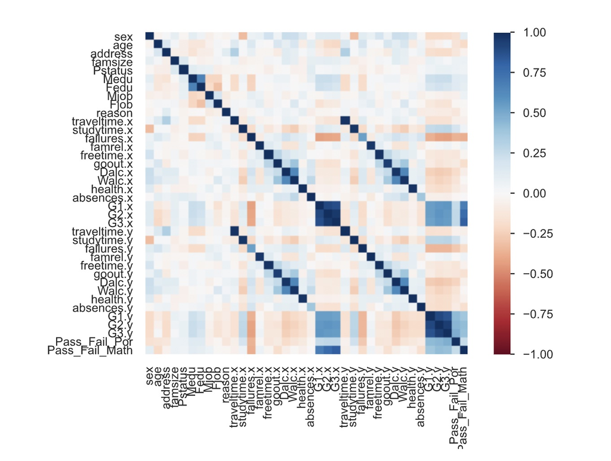

## 3.2 Models

## 3.2.1 Partial Dependence Plot (PDP)

The partial dependence plot is used shows the marginal effect one or two features have on the predicted outcome. In this analysis a PDP was for single variables as shown below. This shows a relationship with the freetime for both the Math and Portuguese scores.

```r
# Load required packages
library(randomForest)  # for fitting random forests
```

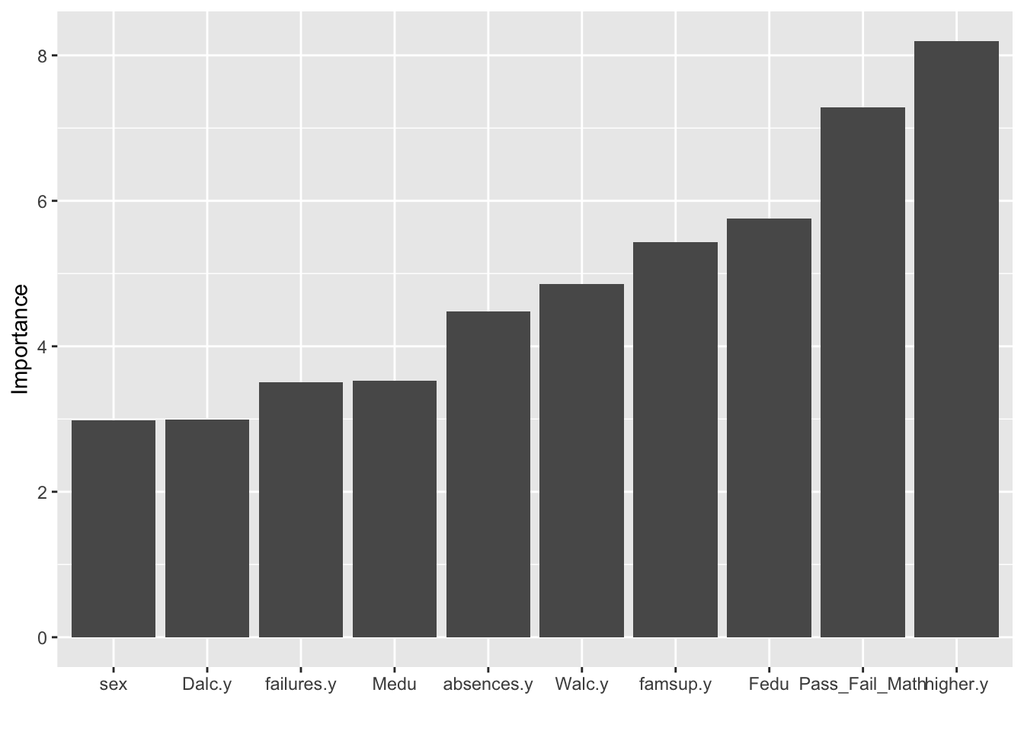

```r
library(pdp)           # for partial dependence plots
library(vip)           # for variable importance plots
# Fit a random forest to the Boston housing data
set.seed(101)  # for reproducibility
por_rf <- randomForest(Pass_Fail_Por ~ sex + age + address+famsize+Pstatus+Medu+Fedu+Mjob+Fjob+reason+nursery+internet+guardian.y+traveltime.y+studytime.y+failures.y+schoolsup.y+famsup.y + paid.y   + activities.y +higher.y + romantic.y +   famrel.y   +   freetime.y   +    goout.y        +Dalc.y + Walc.y   +     health.y    +   absences.y    +Pass_Fail_Math, data = d_consolidated, importance = TRUE)

# Variable importance plot
vip(por_rf, bar = FALSE, horizontal = FALSE, size = 1.5)
```

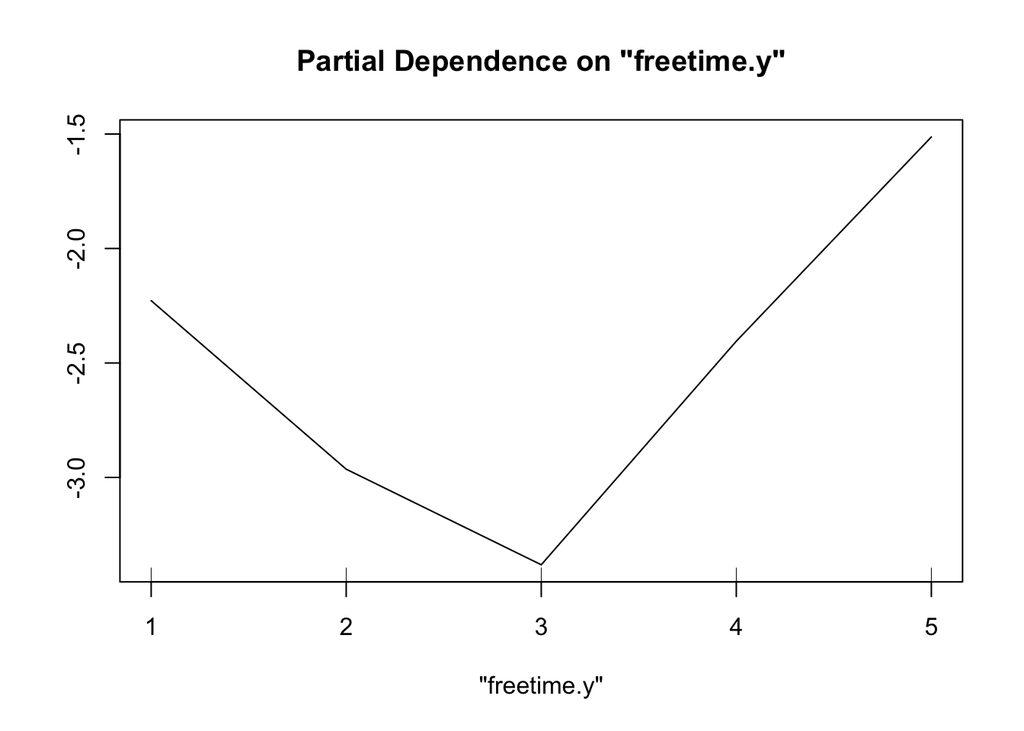

```r
partialPlot(por_rf, pred.data = d_consolidated, x.var = "freetime.y")
```

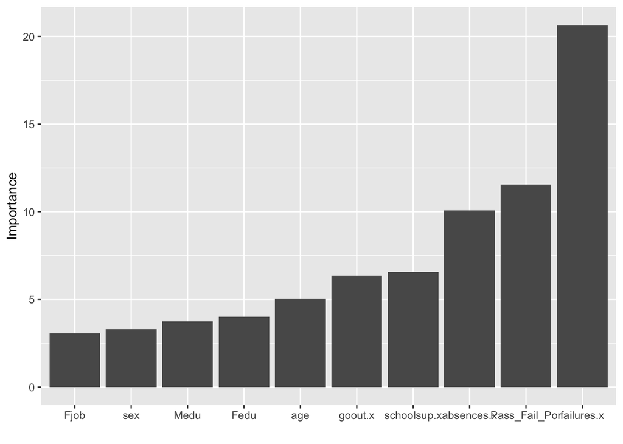

```r
math_rf <- randomForest(Pass_Fail_Math ~ sex + age + address+famsize+Pstatus+Medu+Fedu+Mjob+Fjob+reason+nursery+internet+guardian.x+traveltime.x+studytime.x+failures.x+schoolsup.x+famsup.x + paid.x   + activities.x +higher.x + romantic.x +   famrel.x   +   freetime.x   +    goout.x        +Dalc.x + Walc.x   +     health.x    +   absences.x     +Pass_Fail_Por, data = d_consolidated, importance = TRUE)

# Variable importance plot
vip(math_rf, bar = FALSE, horizontal = FALSE, size = 1.5)
```

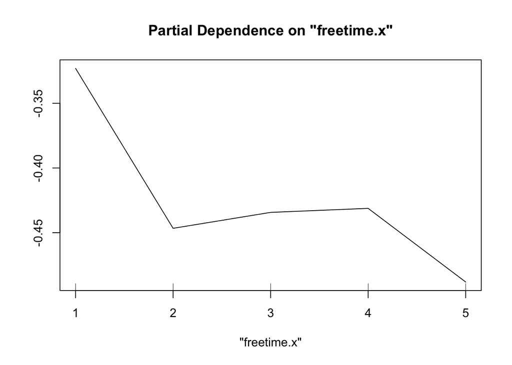

```r
partialPlot(math_rf, pred.data = d_consolidated, x.var = "freetime.x")
```

Multi-predictor PDPs was conducted using the freetime and absences variables, these are shown below. These graphs are showing a relationship with the freetime and absences variables.

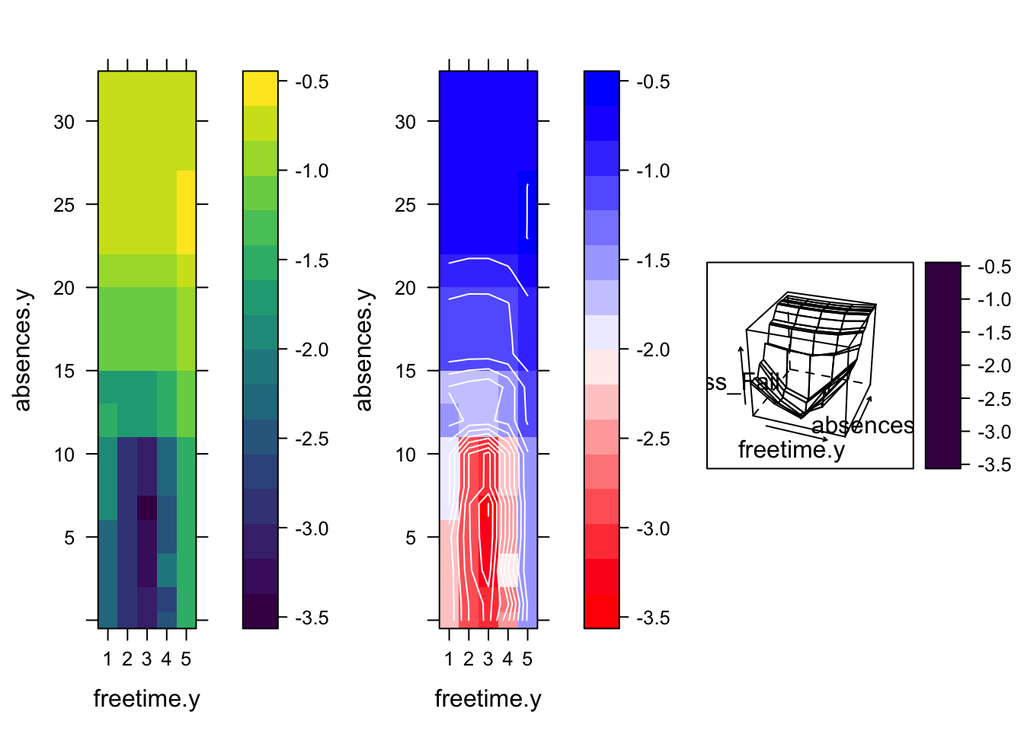

```r
# Compute partial dependence data for freetime and absences
pd <- pdp::partial(por_rf, pred.var = c("freetime.y", "absences.y"))

# Default PDP
pdp1 <- plotPartial(pd)

# Add contour lines and use a different color palette
rwb <- colorRampPalette(c("red", "white", "blue"))
pdp2 <- plotPartial(pd, contour = TRUE, col.regions = rwb)

# 3-D surface
pdp3 <- plotPartial(pd, levelplot = FALSE, zlab = "Pass_Fail", colorkey = TRUE,
                    screen = list(z = -20, x = -60))


grid.arrange(pdp1, pdp2, pdp3, ncol = 3)
```

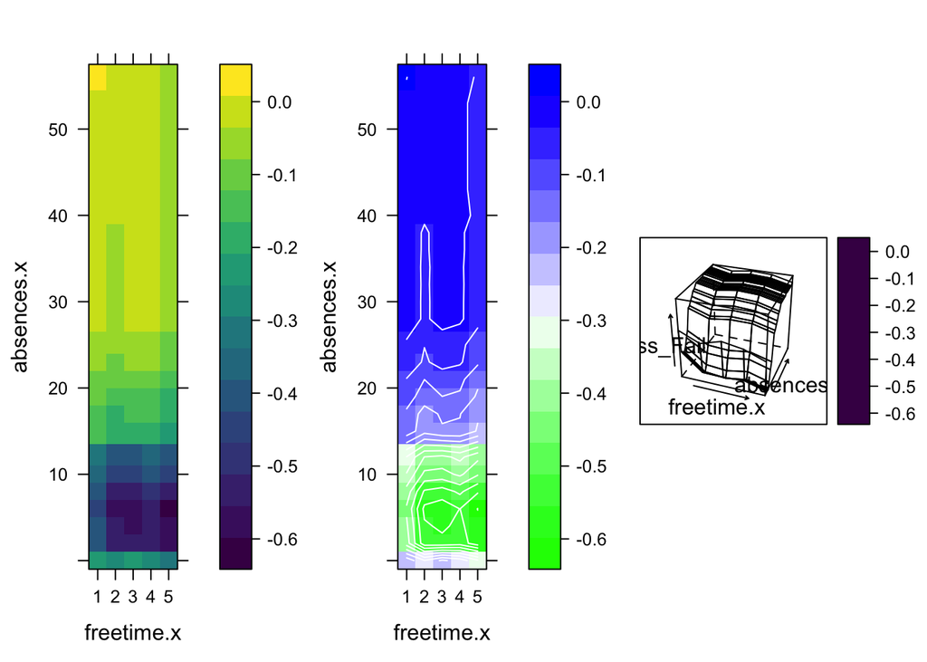

```r
# Compute partial dependence data for freetime and absences
pd <- pdp::partial(math_rf, pred.var = c("freetime.x", "absences.x"))

# Default PDP
pdp1 <- plotPartial(pd)

# Add contour lines and use a different color palette
rwb <- colorRampPalette(c("green", "white", "blue"))
pdp2 <- plotPartial(pd, contour = TRUE, col.regions = rwb)

# 3-D surface
pdp3 <- plotPartial(pd, levelplot = FALSE, zlab = "Pass_Fail", colorkey = TRUE,
                    screen = list(z = -20, x = -60))

# Figure 5
grid.arrange(pdp1, pdp2, pdp3, ncol = 3)
```

The PDP is shown at the side

## 3.2.2 Decision Trees

The choice of the model of random forest was made to determine the important variables as well as easy to verify the results as decision trees allow easier explanations. One key issue was the hyperparameters for the tree pruning which was set to the following: minsplit=10, maxdept=6 and xval=5.

```r
library(rpart)
library(rattle)
```

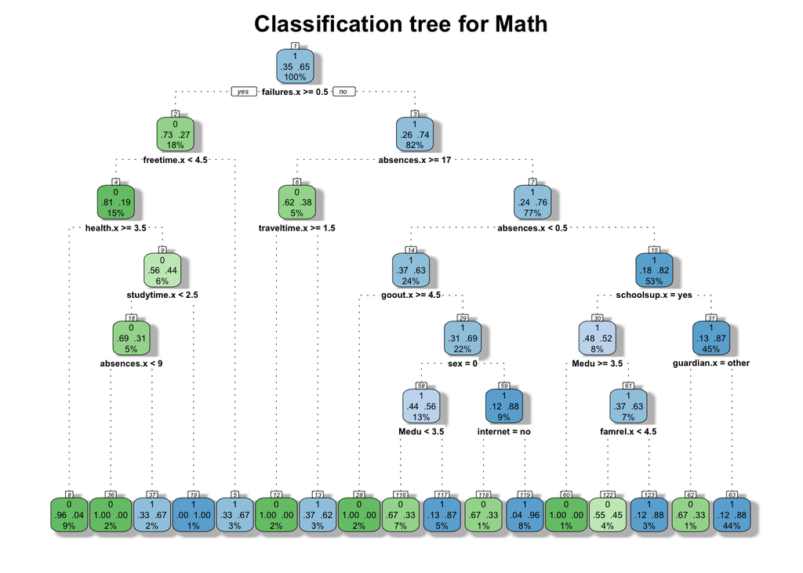

```r
g_pruned_math = rpart(Pass_Fail_Math ~ sex + age + address+famsize+Pstatus+Medu+Fedu+Mjob+Fjob+reason+nursery+internet+guardian.x+traveltime.x+studytime.x+failures.x+schoolsup.x+famsup.x + paid.x   + activities.x +higher.x + romantic.x +   famrel.x   +   freetime.x   +    goout.x        +Dalc.x + Walc.x   +     health.x    +   absences.x     +Pass_Fail_Por, method="class", data=d_consolidated,
                    control=rpart.control(minsplit=10, maxdept=6,xval=5))



# change plot margins (otherwise tree plot will not display fully)
par(mar = c(2, 2, 2, 2))
# cross-validation error plot
#plotcp(g_pruned_math)
# plot splits in decision tree
#plot(g_pruned_math, uniform=TRUE, main="Classification Tree for Heart Disease")
#text(g_pruned_math, use.n=TRUE, all=TRUE, cex=.8)
#printcp(g_pruned_math)
fancyRpartPlot(g_pruned_math,main="Classification tree for Math")
```

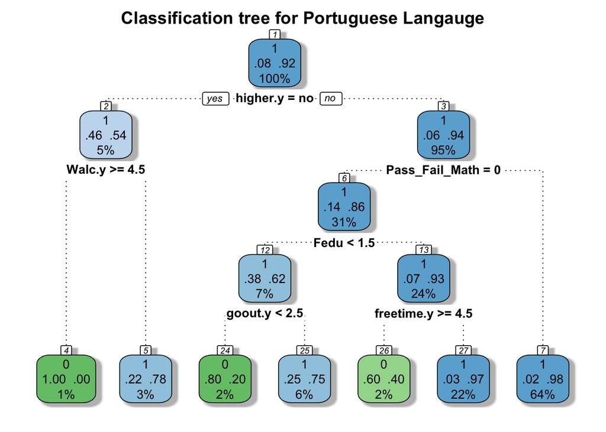

```r
g_pruned_por = rpart(Pass_Fail_Por ~ sex + age + address+famsize+Pstatus+Medu+Fedu+Mjob+Fjob+reason+nursery+internet+guardian.y+traveltime.y+studytime.y+failures.y+schoolsup.y+famsup.y + paid.y   + activities.y +higher.y + romantic.y +   famrel.y   +   freetime.y   +    goout.y        +Dalc.y + Walc.y   +     health.y    +   absences.y     +Pass_Fail_Math, method="class", data=d_consolidated,
                    control=rpart.control(minsplit=10, maxdept=6,xval=5))



# change plot margins (otherwise tree plot will not display fully)
par(mar = c(2, 2, 2, 2))
# cross-validation error plot
#plotcp(g_pruned_math)
# plot splits in decision tree
#plot(g_pruned_math, uniform=TRUE, main="Classification Tree for Heart Disease")
#text(g_pruned_math, use.n=TRUE, all=TRUE, cex=.8)
#printcp(g_pruned_math)
fancyRpartPlot(g_pruned_por,main="Classification tree for Portuguese Langauge")
```

Decision Trees

## 3.2.3 Unsupervised - K-means

```r
library(cluster)
# define a function to get the silhouette across different k
silhouette_k_sweep = function(cluster_fn, df, max_k=15){
  sil_scores = c()
  loss_scores = c()
  for(k in 2:max_k){
    # build cluster model
 #   print(paste0("K",k))
  #  print(sil_scores)
  #  print(loss_scores)
    g_k = cluster_fn(df, k)
   # print(g_k)
    # get the loss for given value of k (requires different code for different cluster_fn)
    if(identical(cluster_fn, kmeans)){
   #   print("in here0")
      loss_scores[k-1] = g_k$tot.withinss
    } else if(identical(cluster_fn, pam)){
  #    print("in here1")
      loss_scores[k-1] = g_k$objective[1]
    }else
    {
 #     print("in here2")
      loss_scores[k-1]=g_k$objective[1]
    }
  #   print("in here4")
    # get the silhoutte scores for all samples and average
    if(identical(cluster_fn, kmeans)){
       sil_scores[k-1] = mean(silhouette(g_k$cluster, dist(df))[,3])
    } else if(identical(cluster_fn, pam)){

      t_predict <-predict(g_k)
     # t_predict$classification
     sil_scores[k-1] = mean(silhouette(t_predict$classification, dist(df))[,3])
    }



  }
  # find the optimal k by find the max of the silhoutte scores

  opt_k_sil = which.max(sil_scores) + 1
  return(list(loss_scores=loss_scores, sil_scores=sil_scores, opt_k_sil=opt_k_sil))
}
```

```r
library(vcd)     # For association plots
library(readr)   # read_csv() is fast read facility
#features_por = subset(d_consolidated, select=-c(G1.x,G2.x,G3.x,G1.y,G2.y,G3.y,Pass_Fail_Por,Pass_Fail_Math))

features_por <- subset(d_consolidated, select=c(sex,address,famsize,absences.y,studytime.y,traveltime.y,freetime.y,failures.y))
features_math <- subset(d_consolidated, select=c(sex,address,famsize,absences.x,studytime.x,traveltime.x,freetime.x,failures.x))
#labels_por = subset(d_consolidated, select=c(Pass_Fail_Por))
d_consolidated$labels_por <- ifelse(d_consolidated$G3.y <= 5, 1,
                          ifelse(d_consolidated$G3.y <= 10 & d_consolidated$G3.y>5, 2,
                          ifelse(d_consolidated$G3.y <= 15 & d_consolidated$G3.y>10, 3,
                           ifelse(d_consolidated$G3.y <= 20 & d_consolidated$G3.y>15, 4,5))))

d_consolidated$labels_math <- ifelse(d_consolidated$G3.x <= 5, 1,
                          ifelse(d_consolidated$G3.x <= 10 & d_consolidated$G3.x>5, 2,
                          ifelse(d_consolidated$G3.x <= 15 & d_consolidated$G3.y>10, 3,
                           ifelse(d_consolidated$G3.x <= 20 & d_consolidated$G3.y>15, 4,4))))

sil_sweep_kmeans = silhouette_k_sweep(kmeans, features_por,15)
sil_sweep_kmeans$opt_k_sil
```

```
## [1] 2
```

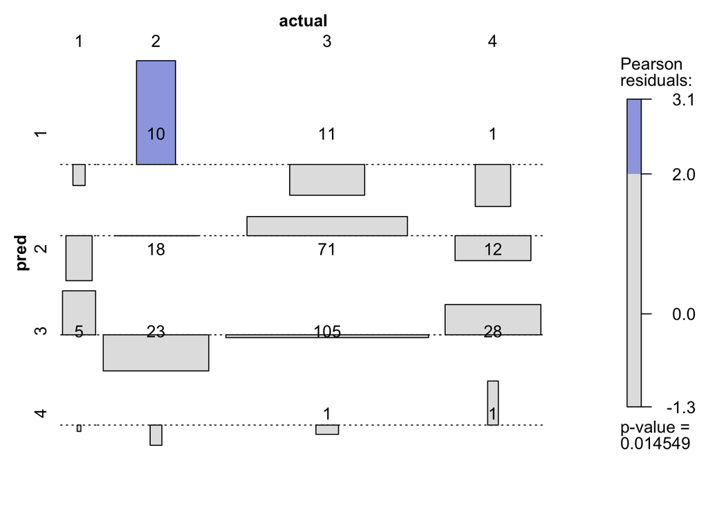

```r
cl_por<-kmeans(features_por, centers = 4, nstart = 2, iter.max = 50)


df<-data.frame(predicted = cl_por$cluster, actual = d_consolidated$labels_por)

tb<-table(pred=df$predicted,actual=df$actual)
assoc(tb, shade = T, labeling = labeling_values)
```

```r
sil_sweep_kmeans = silhouette_k_sweep(kmeans, features_math,15)
sil_sweep_kmeans$opt_k_sil
```

```
## [1] 2
```

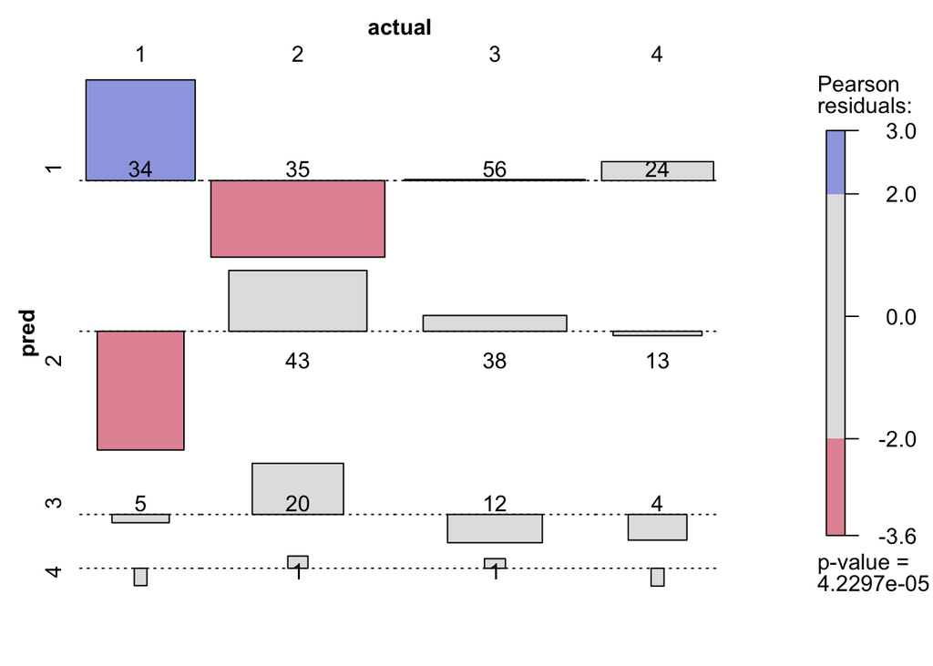

```r
cl_math<-kmeans(features_math, centers = 4, nstart = 2, iter.max = 50)

df_math<-data.frame(predicted = cl_math$cluster, actual = d_consolidated$labels_math)

tb_m<-table(pred=df_math$predicted,actual=df_math$actual)
assoc(tb_m, shade = T, labeling = labeling_values)
```

## 3.2.3 Parameter tuning for XGboost

nrounds[default=100]  
It controls the maximum number of iterations. For classification, it is similar to the number of trees to grow.  
eta[default=0.3][range: (0,1)] It controls the learning rate, i.e., the rate at which our model learns patterns in data. After every round, it shrinks the feature weights to reach the best optimum.  
Lower eta leads to slower computation. It must be supported by increase in nrounds. Typically, it lies between 0.01 - 0.3  
gamma[default=0][range: (0,Inf)]  
It controls regularization (or prevents overfitting). The optimal value of gamma depends on the data set and other parameter values. Higher the value, higher the regularization. Regularization means penalizing large coefficients which don’t improve the model’s performance. default = 0 means no regularization.

max_depth[default=6][range: (0,Inf)]  
It controls the depth of the tree. min_child_weight[default=1][range:(0,Inf)]  
In regression, it refers to the minimum number of instances required in a child node. In classification, if the leaf node has a minimum sum of instance weight (calculated by second order partial derivative) lower than min_child_weight, the tree splitting stops. In simple words, it blocks the potential feature interactions to prevent overfitting.  
subsample[default=1][range: (0,1)] It controls the number of samples (observations) supplied to a tree.  
Typically, its values lie between (0.5-0.8) colsample_bytree[default=1][range: (0,1)] It control the number of features (variables) supplied to a tree

```r
library(e1071)
library(caret)
library(xgboost)
dmatrix_data = subset(d_consolidated, select=c(sex,address,famsize,absences.y,studytime.y,traveltime.y,freetime.y,failures.y))

new_tr <- model.matrix(~.+0,data = dmatrix_data,with=F)
labels <- as.numeric(d_consolidated$Pass_Fail_Math)-1

#g_xgb_weather = xgboost::xgboost(data=new_tr, label=labels, max.depth=2, eta=0.01,
 #               nrounds=500, objective="binary:logistic", verbose=0)


# find best parameters
best_param <- list()
best_seednumber <- 1234
best_rmse <- Inf
best_rmse_index <- 0

set.seed(123)

dtrain <- xgb.DMatrix(data = new_tr,label = labels)


for (iter in 1:100) {
  param <- list(objective = "binary:logistic",
                eval_metric = "rmse",
                max_depth = sample(6:10, 1),
                eta = runif(1, .01, .3), # Learning rate, default: 0.3
               subsample = runif(1, .6, .9),
             nrounds=iter ,
              colsample_bytree = runif(1, .5, .8),
                min_child_weight = sample(1:40, 1),
                max_delta_step = sample(1:10, 1)
  )
  cv.nround <-  1000
  cv.nfold <-  5 # 5-fold cross-validation
  seed.number  <-  sample.int(10000, 1) # set seed for the cv
  set.seed(seed.number)
  mdcv <- xgb.cv(data = dtrain, params = param,
                 nfold = cv.nfold, nrounds = cv.nround,
                 verbose = F, early_stopping_rounds = 8, maximize = FALSE)

  min_rmse_index  <-  mdcv$best_iteration
  min_rmse <-  mdcv$evaluation_log[min_rmse_index]$test_rmse_mean

  if (min_rmse < best_rmse) {
    best_rmse <- min_rmse
    best_rmse_index <- min_rmse_index
    best_seednumber <- seed.number
    best_param <- param
  }
}

best_param
```

```
## $objective
## [1] "binary:logistic"
##
## $eval_metric
## [1] "rmse"
##
## $max_depth
## [1] 10
##
## $eta
## [1] 0.2824999
##
## $subsample
## [1] 0.6486407
##
## $nrounds
## [1] 14
##
## $colsample_bytree
## [1] 0.6764409
##
## $min_child_weight
## [1] 2
##
## $max_delta_step
## [1] 9
```

```r
# The best index (min_rmse_index) is the best "nround" in the model
nround = best_rmse_index
set.seed(best_seednumber)
xg_mod <- xgboost::xgboost(data = dtrain, params = best_param, nround = nround,
                  verbose = F)
```

[output not shown]

```r
importance_matrix=xgb.importance(colnames(new_tr), model = xg_mod ,
               data = new_tr, label = labels)
```

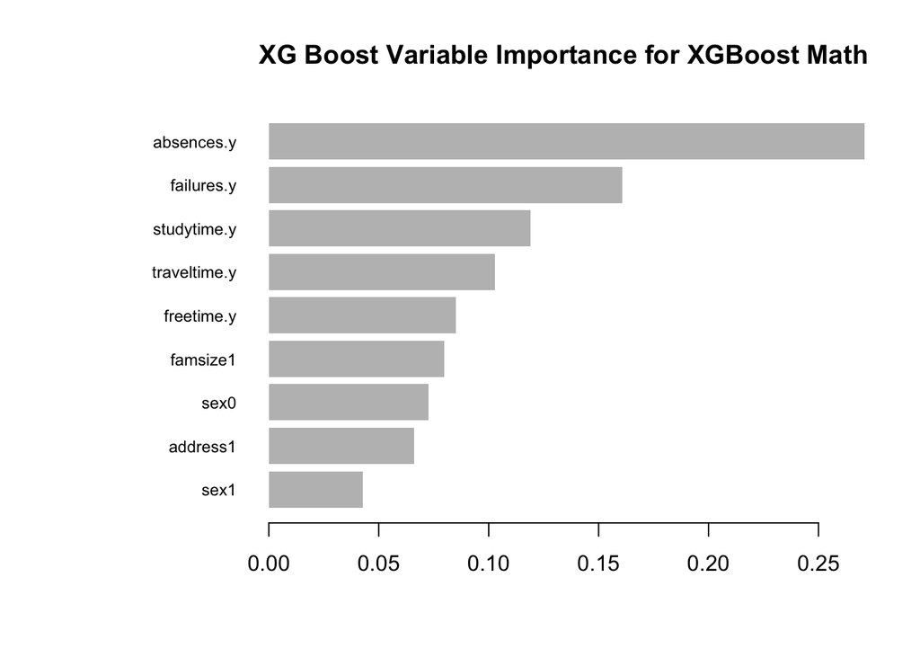

```r
xgb.plot.importance(importance_matrix[,],main="XG Boost Variable Importance for XGBoost Math")
```

# 4.0 Conclusion

This section reviews the analysis of results, discusses the reliability, scope of the conclusion and future work.

## 4.1 Conclusions and Analysis

```r
library(pROC)
```

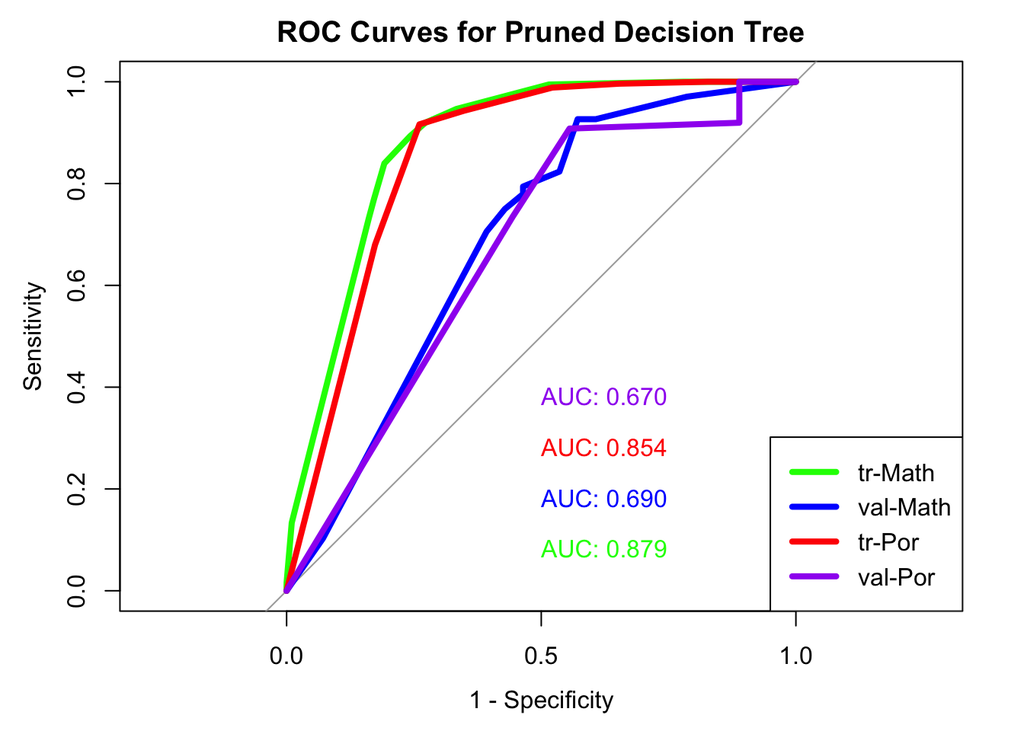

```r
probs_pruned_tr = predict(g_pruned_math, type="prob")[,2]

probs_pruned_val = predict(g_pruned_math, newdata=d_consolidated_val, type="prob")[,2]

probs_pruned_tr_por = predict(g_pruned_por, type="prob")[,2]

probs_pruned_val_por = predict(g_pruned_por, newdata=d_consolidated_val, type="prob")[,2]

roc_pruned_tr = roc(d_consolidated$Pass_Fail_Math, probs_pruned_tr, plot=TRUE, print.auc=TRUE, col="green",
               lwd =4,print.auc.y=0.1, legacy.axes=TRUE, main="ROC Curves for Pruned Decision Tree")
roc_pruned_val = roc(d_consolidated_val$Pass_Fail_Math, probs_pruned_val, plot=TRUE, print.auc=TRUE, col="blue",
                   lwd = 4,print.auc.y=0.2, legacy.axes=TRUE, add=TRUE)
roc_pruned_por = roc(d_consolidated$Pass_Fail_Por, probs_pruned_tr_por, plot=TRUE, print.auc=TRUE, col="red",
                      lwd = 4, print.auc.y=0.3, legacy.axes=TRUE, add=TRUE)
roc_pruned_por = roc(d_consolidated_val$Pass_Fail_Por, probs_pruned_val_por, plot=TRUE, print.auc=TRUE, col="purple",
                   lwd = 4,print.auc.y=0.4, legacy.axes=TRUE, add=TRUE)
legend("bottomright", legend=c("tr-Math", "val-Math", "tr-Por", "val-Por"), col=c("green", "blue","red","purple"), lwd=4)
```

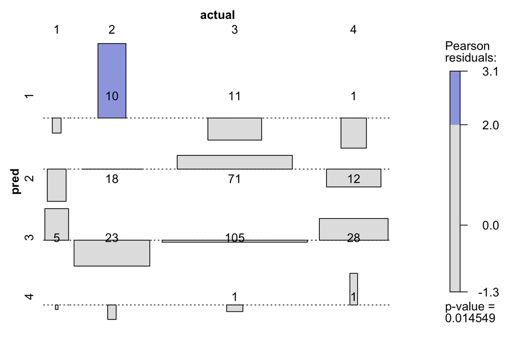

```r
assoc(tb, shade = T, labeling = labeling_values)
```

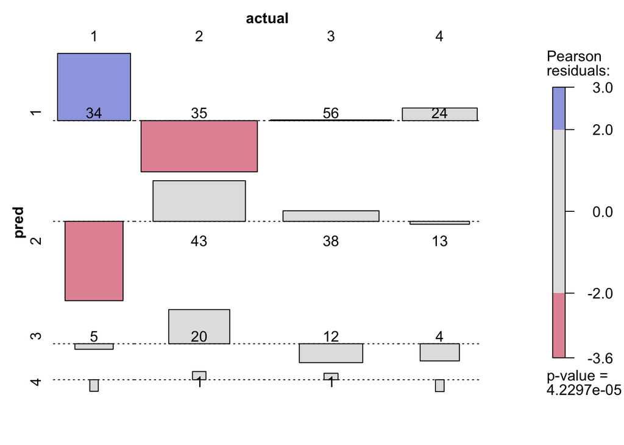

```r
assoc(tb_m, shade = T, labeling = labeling_values)
```

Other variables that are important in Math includes the freetime and absentism at school. In the case of Portuguese language studies, the most important variables are desire to continue to higher education, alcohol consumption and free time were important in determining the pass or fail in this subject area.

The PDP analysis showed marginal effect of freetime and absences features have on the predicted outcome which was interesting in discovery.

The first objective weas achieved by using the PDP model, Decision Tree and XGboost to determine the most significant variables. The creation of an unsupervised k-means model was created to cluster the students into 4 groups.

## 4.2 Future work

There are couple of future work activities available for this research. The first area is the how to handle the number of categorial variables, in this research the majority of variables were categorical and while we used one-hot endcoding and other transformations of categorial variables, future research is needed. Secondly, the use of US based data should be considered as part of the analysis. Lastly, the paramter tuning could be researched further for silhouette and xgboost.

## 4.3.1 Handling of categorial variables

Research on categorical variables will influence future modeling for the high dimensional spaces. This will also impact software packages which utilize the traditional approaches for categorical variables. As such, the wider impact of this research will extend not only to the field of Statistics but further on into Computer Science and Data Science.

## 4.3.2 Using US based data

This analysis was completed using data from a non-US source and it may be interesting to use information US schools to see if similar features of applicable.

## 4.3.3 Parameter Tuning

Consideration for completing more parameter tuning should be researched in the future including the silhouette and xgboost.